# Prediction of Future House Value

Report by Carlos Neves

for the [Amazon Development Center Scotland](https://www.amazondc.com/)’s position of *Machine learning Scientist - Talent Sourcing*.

## Introduction

### Approach:

The value at which a house will sell is represented by a continuous variable. In the absence of clear classes in the data, regression methods are more appropriate for this analysis. As such, linear regression, a simple but efficient regression algorithm, was used as an initial approach for the prediction of house prices considering different factors.

## Set up environment for analysis

Initially all the required packages for the analysis were loaded. These include:

- *data.table*: A package to efficiently load and manage large data files
- *doParallel*: A package that allows to set the number of cores used for parallelized analysis
- *caret*: A package for **C**lassification **A**nd **RE**gression **T**raining, which aims to provide a uniform interface for various machine learning functions
- *gridExtra*: A package that allows to automatically arrange multiple plots
- *dplyr*: A package for easy data manipulation

```r
# Load required packages
library('data.table')
library('doParallel')
library('caret')
library('gridExtra')
library('dplyr')

# Set number of cores to maximum
registerDoParallel(detectCores())
```

*Number of cores available: 24*

Due to the use of randomization during the analysis, a random seed was defined, so the analysis can be consistently reproduced.

```r
# Select random seed
seed <- sample(1:1000, size = 1)
set.seed(seed)
```

*Seed used for this report: 91*

After the required packages/libraries are loaded, the data is read into R using the *fread* function. The variables of interest for this analysis are selected while the data is loaded. These variables are:

- *Price (V2)*: Sale price stated on the transfer deed.
- *Date of Transfer (V3)*: Date when the sale was completed, as stated on the transfer deed
- *Property Type (V5)*: D = Detached, S = Semi-Detached, T = Terraced, F = Flats/Maisonettes, O = Other
- *Lease duration (V7)*: Relates to the tenure: F = Freehold, L= Leasehold etc.
- *Town/City (V12)*: Location of the property

```r
# Create a vector with the number of the relevant variables
cols_interest <- c(2, 3, 5, 7, 12)

# Read file
data <- fread('pp-complete.csv', header = FALSE, select = cols_interest, data.table = FALSE, verbose = FALSE, showProgress = FALSE)

# Check the data structure
head(data)
```

```
##      V2               V3 V5 V7                 V12
## 1 42000 1995-12-21 00:00  S  F NEWCASTLE UPON TYNE
## 2 95000 1995-03-03 00:00  S  F               GRAYS
## 3 74950 1995-10-03 00:00  D  F          MIDDLEWICH
## 4 43500 1995-11-14 00:00  S  F          BILLINGHAM
## 5 63000 1995-09-08 00:00  S  F        CLEATOR MOOR
## 6 29995 1995-05-12 00:00  S  F             WISBECH
```

```r
# Remove variables not required any more from environment
rm(cols_interest, seed)
```

# Data pre-processing

Looking at the first entries of the data, it is clear that the *Date of Transfer (V3)* is excessively descriptive for the purpose of this analysis, as only the year of transfer is of interest. Also the *Town/City (V12)* contains too many possible values. As such these variables were simplified by maintaining only the year of the *Date of Transfer* and a logic vector of whether or not the property is in London.

```r
# Check for all the possible variants of LONDON's location
unique(grep(pattern = 'LONDON', data$V12, value = TRUE))
```

```
## [1] "LONDON"
```

```r
# Add the new simplified variables
data <- data %>%
        mutate('Date' = gsub(pattern = '-[0-9]{2}-[0-9]{2} [0-9]{2}:[0-9]{2}', replacement = '', data$V3)) %>%
        mutate('London' = data$V12 =='LONDON')

###
# Quick check for issues with the variable simplification #
# Is the proportion of houses in London maintained?
mean('LONDON' == data$V12)
```

```
## [1] 0.07847126
```

```r
mean(data$London)
```

```
## [1] 0.07847126
```

```r
# How does the data look now? (look at random entries)
data[sample(nrow(data), size = 15), c(2, 6, 5, 7)]
```

```
##                        V3 Date            V12 London
## 12343578 2005-02-10 00:00 2005         LONDON   TRUE
## 9969902  2003-03-14 00:00 2003     NOTTINGHAM  FALSE
## 12124568 2005-04-18 00:00 2005     WEDNESBURY  FALSE
## 15646830 2009-02-18 00:00 2009      DROITWICH  FALSE
## 23062595 2017-11-03 00:00 2017         ALFORD  FALSE
## 10029431 2003-03-28 00:00 2003 STOKE-ON-TRENT  FALSE
## 23679158 2018-03-15 00:00 2018      TONBRIDGE  FALSE
## 8419862  2002-06-17 00:00 2002      LIVERPOOL  FALSE
## 4343386  1999-01-15 00:00 1999      HASLEMERE  FALSE
## 15879805 2009-03-20 00:00 2009   WEST BYFLEET  FALSE
## 23338637 2018-03-29 00:00 2018      KETTERING  FALSE
## 924691   1996-02-23 00:00 1996      YELVERTON  FALSE
## 13974193 2007-01-19 00:00 2007    CROWBOROUGH  FALSE
## 9524203  2003-08-07 00:00 2003        CRAWLEY  FALSE
## 8961413  2003-08-15 00:00 2003        GRIMSBY  FALSE
```

```r
# Remove old variables
data <- data %>%
        select(-V3) %>%
        select(-V12)

# Rename variables
names(data) <- c('Price', 'Type', 'Lease', 'Date', 'London')
head(data)
```

```
##   Price Type Lease Date London
## 1 42000    S     F 1995  FALSE
## 2 95000    S     F 1995  FALSE
## 3 74950    D     F 1995  FALSE
## 4 43500    S     F 1995  FALSE
## 5 63000    S     F 1995  FALSE
## 6 29995    S     F 1995  FALSE
```

With the data cleaned, each variable was checked for irregularities, such as missing values.

```r
# Check Property type
class(data$Type)
```

```
## [1] "character"
```

```r
unique(data$Type)
```

```
## [1] "S" "D" "F" "T" "O"
```

```r
# 'O' stands for other. It is unclear how heterogeneous 'other' is, so these entries were considered uninformative and removed from the analysis
idx_type <- which(data$Type == 'O')
data <- data[-idx_type, ]
unique(data$Type)
```

```
## [1] "S" "D" "F" "T"
```

```r
# Any missing values?
sum(is.na(data$Type))
```

```
## [1] 0
```

```r
# Check Lease duration
class(data$Lease)
```

```
## [1] "character"
```

```r
unique(data$Lease)
```

```
## [1] "F" "L" "U"
```

```r
# 'U' is not described in the variable descriptions provided. It can be assumed to stand for 'unknown', so these entries were removed from the analysis as uninformative.
idx_lease <- which(data$Lease == 'U')
data <- data[-idx_lease, ]
unique(data$Lease)
```

```
## [1] "F" "L"
```

```r
# Any missing values?
sum(is.na(data$Lease))
```

```
## [1] 0
```

```r
# Check Date of transfer
class(data$Date)
```

```
## [1] "character"
```

```r
unique(data$Date)
```

```
##  [1] "1995" "1996" "1997" "1998" "1999" "2000" "2001" "2002" "2003" "2004"
## [11] "2005" "2006" "2007" "2008" "2009" "2010" "2011" "2012" "2013" "2014"
## [21] "2015" "2016" "2017" "2018"
```

```r
# The 2015 data seems to contain some information from 2016! These entries were removed as the focus of the analysis is on the values up to 2015
idx_date <- which(data$Date == '2016')
data <- data[-idx_date, ]
unique(data$Date)
```

```
##  [1] "1995" "1996" "1997" "1998" "1999" "2000" "2001" "2002" "2003" "2004"
## [11] "2005" "2006" "2007" "2008" "2009" "2010" "2011" "2012" "2013" "2014"
## [21] "2015" "2017" "2018"
```

```r
# Any missing values?
sum(is.na(data$Date))
```

```
## [1] 0
```

```r
# Check Location
class(data$London)
```

```
## [1] "logical"
```

```r
unique(data$London)
```

```
## [1] FALSE  TRUE
```

```r
# Convert logical vector into factor for ease of analysis
data$London <- as.factor(data$London)
# Change factor level names
mean(data$London == 'TRUE') # proportion of properties in London prior to conversion
```

```
## [1] 0.07871144
```

```r
levels(data$London) <- c('out London', 'in London')
mean(data$London == 'in London') # proportion of properties in London after conversion
```

```
## [1] 0.07871144
```

```r
# Any missing values?
sum(is.na(data$London))
```

```
## [1] 0
```

```r
# Check Price
class(data$Price)
```

```
## [1] "integer"
```

```r
data$Price <- as.numeric(data$Price) # convert into a numerical vector
class(data$Price)
```

```
## [1] "numeric"
```

```r
# Any missing values?
sum(is.na(data$Price))
```

```
## [1] 0
```

```r
# Remove variables not required any more from environment
rm(idx_type, idx_lease, idx_date)
```

# Data splitting

To perform a consistent analysis, the data was split into train, validation and test sets. For this analysis, the test set is considered to be all the entries from 2015, while the remaining entries are used for model training and selection.

```r
# Set Test data aside
idx_test <- which(data$Date == '2015')
train_val <- data[-idx_test, ]
test <- data[idx_test, ]

###
# Quick check for issues with the test set partition
# Is the test set the expected size?
sum(data$Date == '2015')
```

```
## [1] 989748
```

```r
nrow(test)
```

```
## [1] 989748
```

```r
# Is the train/valiation set the expected size?
nrow(data) - length(idx_test)
```

```
## [1] 21655523
```

```r
nrow(train_val)
```

```
## [1] 21655523
```

```r
# Were the dates properly split?
unique(train_val$Date)
```

```
##  [1] "1995" "1996" "1997" "1998" "1999" "2000" "2001" "2002" "2003" "2004"
## [11] "2005" "2006" "2007" "2008" "2009" "2010" "2011" "2012" "2013" "2014"
## [21] "2017" "2018"
```

```r
unique(test$Date)
```

```
## [1] "2015"
```

```r
###

# Set Validation data aside
# Create a train set that is 70% of the train/validation data
idx_train <- createDataPartition(train_val$Date, p = 0.7)[[1]]
train <- train_val[idx_train, ]
validation <- train_val[-idx_train, ]

###
# Quick check for issues with the validation set partition
# Are the sets the expected proportions?
nrow(train)/nrow(train_val)
```

```
## [1] 0.7000004
```

```r
nrow(validation)/nrow(train_val)
```

```
## [1] 0.2999996
```

```r
# Is the data homogeneously split?
round(table(train$Date)/length(train$Date), digits = 3)
```

```
##
##  1995  1996  1997  1998  1999  2000  2001  2002  2003  2004  2005  2006
## 0.037 0.045 0.050 0.048 0.055 0.052 0.057 0.062 0.057 0.057 0.049 0.061
##  2007  2008  2009  2010  2011  2012  2013  2014  2017  2018
## 0.059 0.030 0.029 0.031 0.031 0.031 0.037 0.045 0.046 0.032
```

```r
round(table(validation$Date)/length(validation$Date), digits = 3)
```

```
##
##  1995  1996  1997  1998  1999  2000  2001  2002  2003  2004  2005  2006
## 0.037 0.045 0.050 0.048 0.055 0.052 0.057 0.062 0.057 0.057 0.049 0.061
##  2007  2008  2009  2010  2011  2012  2013  2014  2017  2018
## 0.059 0.030 0.029 0.031 0.031 0.031 0.037 0.045 0.046 0.032
```

```r
# Remove variables not required any more from environment
rm(data, idx_test, idx_train, train_val)

# Existing variables
ls()
```

```
## [1] "test"       "train"      "validation"
```

# Exploratory data analysis

With all the data processed and split appropriately, the distribution of the house prices and how these relate to the predictor (categorical) variables was explored.

This analysis will focus on three variables:

- Lease duration
- Property type
- Location (inside or outside of London)

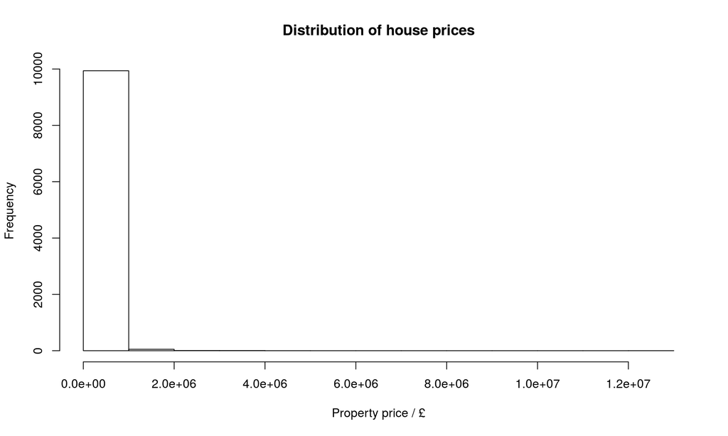

```r
# Take a subset sample of the data to speed the exploratory analysis
idx_sample <- sample(nrow(train), size = 10000)
hist(train$Price[idx_sample], xlab = 'Property price / £', main = 'Distribution of house prices')
```

The distribution of prices is highly skewed. As this could interfere with the regression analysis, the house prices were log transformed to correct for the observed skewness.

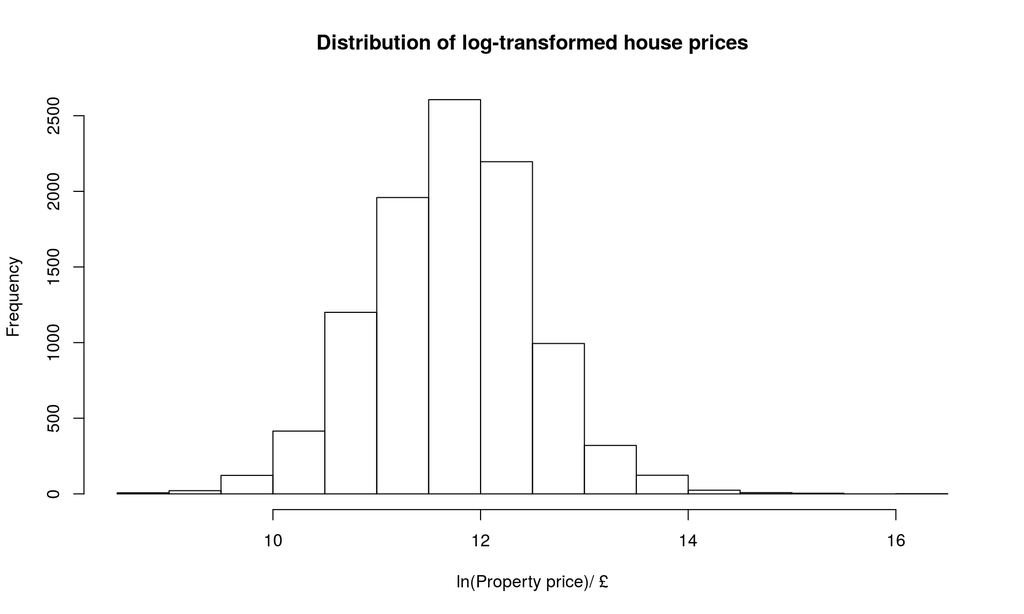

```r
hist(log(train$Price[idx_sample]), xlab = 'ln(Property price)/ £', main = 'Distribution of log-transformed house prices')
```

The price distribution is now much more regular (normally distributed).

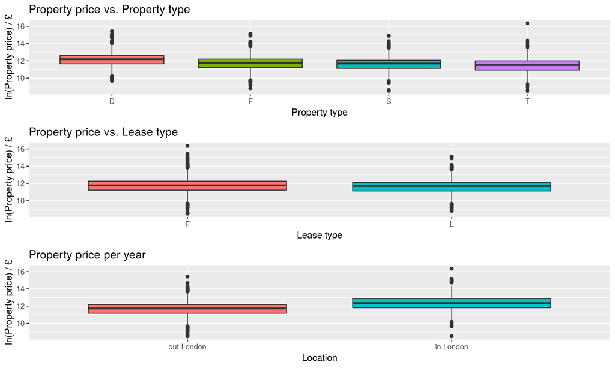

```r
# Plot the relationship between price and the predictor variables

# Plot Property price vs. Property type
p_type <- ggplot(train[idx_sample, ], aes(x = Type, y = log(Price), fill = Type)) +
            geom_boxplot() +
            theme(legend.position = 'none') +
            ggtitle('Property price vs. Property type') +
            ylab('ln(Property price) / £') +
            xlab('Property type')

# Plot Property price vs. Lease  type
p_lease <- ggplot(train[idx_sample, ], aes(x = Lease, y = log(Price), fill = Lease)) +
            geom_boxplot() +
            theme(legend.position = 'none') +
            ggtitle('Property price vs. Lease type') +
            ylab('ln(Property price) / £') +
            xlab('Lease type')

# Plot Property price vs. Location
p_london <- ggplot(train[idx_sample, ], aes(x = London, y = log(Price), fill = London)) +
            geom_boxplot() +
            theme(legend.position = 'none') +
            ggtitle('Property price per year') +
            ylab('ln(Property price) / £') +
            xlab('Location')

# Make image of all plots
grid.arrange(p_type, p_lease, p_london)

# Plot Property price vs. Date (save for latter)
p_date <- ggplot(train[idx_sample, ], aes(x = Date, y = log(Price), fill = Date)) +
            geom_boxplot()+theme(legend.position='none')+ggtitle('Property price per year')+ylab('ln(Property price) / £')+xlab('Year of transaction')

# Remove variables not required any more from environment
rm(idx_sample, p_type, p_london, p_lease)
```

All the predictive variables seem to have some influence on the property price. From the plots, the property type and its location (in or out of London) seem to have more varied prices than the lease type.

# Model building

A baseline model was built in order to understand if the trained regression models are in fact useful. The baseline model will assume that the prediction made for the price of the house is the most likely value. As such, it will simply predict the median price of all the houses, regardless of the house specifications. Two linear regressions, either considering *Lease type* or not, were trained to predict the house price. To increase the accuracy of these two models, k-fold cross-validation (k = 10) was used during the model training.

```r
# Base model
model_base <- median(log(train$Price))

# Linear regression model
model_lr1 <- train(log(Price) ~ Type + London, data = train, method = 'lm', trControl = trainControl(method = 'cv', number = 10))

model_lr2 <- train(log(Price) ~ Type + London + Lease, data = train, method = 'lm', trControl = trainControl(method = 'cv', number = 10))
```

# Model selection

Since the outcome variable is continuous and modelled using regression analysis, the root mean square error ([RMSE](https://en.wikipedia.org/wiki/Root-mean-square_deviation)) performance metric was used to compare models. The RMSE provides a good estimate of the total difference between the estimated and real property prices, so that the smaller the value the more accurate the predictions are expected to be. Because the model output variable was a logarithm, it needs to be exponentiated to match the prices and make he RMSE more interpretable.

```r
#Cross-validate base model
postResample(pred = exp(rep(model_base, times = nrow(validation))), obs = validation$Price)[1]
```

```
##     RMSE
## 210257.1
```

```r
# Cross-validate model 1
summary(model_lr1)
```

```
##
## Call:
## lm(formula = .outcome ~ ., data = dat)
##
## Residuals:
##      Min       1Q   Median       3Q      Max
## -12.3380  -0.4886   0.0503   0.4832   7.5660
##
## Coefficients:
##                     Estimate Std. Error t value Pr(>|t|)
## (Intercept)       12.1653687  0.0003813   31907   <2e-16 ***
## TypeF             -0.6669709  0.0006079   -1097   <2e-16 ***
## TypeS             -0.5237021  0.0005157   -1016   <2e-16 ***
## TypeT             -0.7579262  0.0005064   -1497   <2e-16 ***
## `Londonin London`  0.8396465  0.0007262    1156   <2e-16 ***
## ---
## Signif. codes:  0 '***' 0.001 '**' 0.01 '*' 0.05 '.' 0.1 ' ' 1
##
## Residual standard error: 0.7142 on 15158870 degrees of freedom
## Multiple R-squared:  0.1809, Adjusted R-squared:  0.1809
## F-statistic: 8.371e+05 on 4 and 15158870 DF,  p-value: < 2.2e-16
```

```r
postResample(pred = exp(predict(model_lr1, newdata = validation)), obs = validation$Price)[1]
```

```
##     RMSE
## 198476.9
```

```r
# Cross-validate model 2
summary(model_lr2)
```

```
##
## Call:
## lm(formula = .outcome ~ ., data = dat)
##
## Residuals:
##      Min       1Q   Median       3Q      Max
## -12.6086  -0.4829   0.0488   0.4844   7.5398
##
## Coefficients:
##                     Estimate Std. Error t value Pr(>|t|)
## (Intercept)       12.1759586  0.0003806 31987.8   <2e-16 ***
## TypeF             -0.4052335  0.0009305  -435.5   <2e-16 ***
## TypeS             -0.5133044  0.0005141  -998.4   <2e-16 ***
## TypeT             -0.7423012  0.0005059 -1467.2   <2e-16 ***
## `Londonin London`  0.8378499  0.0007230  1158.9   <2e-16 ***
## LeaseL            -0.2792450  0.0007541  -370.3   <2e-16 ***
## ---
## Signif. codes:  0 '***' 0.001 '**' 0.01 '*' 0.05 '.' 0.1 ' ' 1
##
## Residual standard error: 0.711 on 15158869 degrees of freedom
## Multiple R-squared:  0.1883, Adjusted R-squared:  0.1883
## F-statistic: 7.031e+05 on 5 and 15158869 DF,  p-value: < 2.2e-16
```

```r
postResample(pred = exp(predict(model_lr2, newdata = validation)), obs = validation$Price)[1]
```

```
##     RMSE
## 198195.4
```

From the regression summaries, it would seem that all the predictors considered are significant for the model. In fact, both models have a root mean square error lower than the base model, with the linear regression considering the three different predictors showing a slightly improved performance. As such, the latter model (*model_lr2*) was selected to predict the house values.